# Bayesian workshop - 20 November 2020

## An analysis a non-Bayesian would find very difficult to do

So far we’ve seen analyses that could also be done using non-Bayesian methods, with `lm()`, `aov()`, or `lmer()`. I’ve illustrated some of the advantages of Bayesian approaches, but I haven’t illustrated what I meant when I said “You can build on simple models to do things that are much more complicated.”

Let’s start by reading in the data and scaling it.

```r
dat <- read.csv("Protea_traits_dataset_for_workshop.csv",
                header = TRUE,
                na.strings = ".")

phys_traits <- c("Ks", "KL_Units", "Photo", "Cond", "WUE_Intrinsic")
morph_traits <- c("WD", "BW_dry_avg", "Thick_cm", "Area_cm2", "LMA_g.cm2", "LWR", "LD_g.cm3",
                  "Length_mm_Top", "Density_mm2_Top", "SPI_Top")

for (trait in c(phys_traits, morph_traits)) {
  dat[[trait]] <- as.numeric(scale(dat[[trait]]))
}
```

Now let’s see how each physiological trait is associated with the morphological traits.[^1]

```r
fit <- vector(mode = "list", length = length(phys_traits))
names(fit) <- phys_traits
plots <- vector(mode = "list", length = length(phys_traits))
names(plots) <- phys_traits
for (phys in phys_traits) {
  model_formula <- paste(phys, " ~ ", paste(morph_traits, collapse = " + "), sep = "")
  fit[[phys]] <- stan_glm(model_formula,
                          data = dat,
                          family = gaussian(),
                          refresh = 0)
  print(summary(fit[[phys]], digits = 3, probs = c(0.025, 0.1, 0.5, 0.9, 0.975)))
  plots[[phys]] <- plot(fit[[phys]])
}
```

```
Model Info:
 function:     stan_glm
 family:       gaussian [identity]
 formula:      "Ks ~ WD + BW_dry_avg + Thick_cm + Area_cm2 + LMA_g.cm2 + LWR + LD_g.cm3 + Length_mm_Top + Density_mm2_Top + SPI_Top"
 algorithm:    sampling
 sample:       4000 (posterior sample size)
 priors:       see help('prior_summary')
 observations: 151
 predictors:   11

Estimates:
                  mean   sd     2.5%   10%    50%    90%    97.5%
(Intercept)     -0.002  0.076 -0.151 -0.100 -0.001  0.097  0.145
WD              -0.154  0.106 -0.365 -0.287 -0.153 -0.017  0.054
BW_dry_avg      -0.115  0.178 -0.467 -0.344 -0.112  0.108  0.224
Thick_cm        -0.317  0.629 -1.534 -1.125 -0.313  0.488  0.915
Area_cm2        -0.213  0.167 -0.537 -0.423 -0.213  0.000  0.119
LMA_g.cm2        0.352  0.569 -0.777 -0.373  0.348  1.081  1.465
LWR              0.186  0.171 -0.149 -0.031  0.185  0.402  0.519
LD_g.cm3        -0.612  0.429 -1.456 -1.161 -0.617 -0.058  0.243
Length_mm_Top    1.015  0.576 -0.109  0.272  1.005  1.765  2.137
Density_mm2_Top  0.566  0.353 -0.122  0.116  0.558  1.023  1.241
SPI_Top         -0.498  0.331 -1.161 -0.920 -0.493 -0.074  0.151
sigma            0.938  0.058  0.831  0.866  0.934  1.014  1.061

Fit Diagnostics:
           mean   sd     2.5%   10%    50%    90%    97.5%
mean_PPD -0.003  0.109 -0.222 -0.144  0.000  0.137  0.209

The mean_ppd is the sample average posterior predictive distribution of the outcome variable (for details see help('summary.stanreg')).

MCMC diagnostics
                mcse  Rhat  n_eff
(Intercept)     0.001 1.000 5041
WD              0.002 1.000 4181
BW_dry_avg      0.003 1.000 3437
Thick_cm        0.015 1.000 1740
Area_cm2        0.003 1.000 3406
LMA_g.cm2       0.013 1.000 1813
LWR             0.003 1.000 3717
```

[output cut: 194 more lines]

```
WD              0.002 1.000 4542
BW_dry_avg      0.003 1.000 3063
Thick_cm        0.015 1.001 1860
Area_cm2        0.003 1.000 2857
LMA_g.cm2       0.013 1.001 1936
LWR             0.003 1.000 3458
LD_g.cm3        0.010 1.001 1886
Length_mm_Top   0.013 1.000 1945
Density_mm2_Top 0.008 1.000 2067
SPI_Top         0.008 1.000 1939
sigma           0.001 1.000 3530
mean_PPD        0.002 0.999 4611
log-posterior   0.065 1.003 1571

For each parameter, mcse is Monte Carlo standard error, n_eff is a crude measure of effective sample size, and Rhat is the potential scale reduction factor on split chains (at convergence Rhat=1).
```

```
adding dummy grobs
```

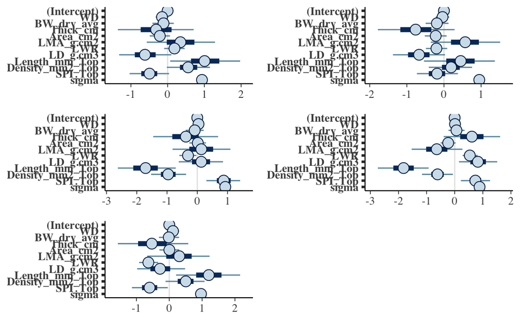

```r
ggarrange(plots = plots, nrow = 3)
```

We know from first principles that some of the response variables will be related to one another, e.g., `Photo` and `Cond`. Let’s put the residuals into a dataframe see whether they’re correlated too.

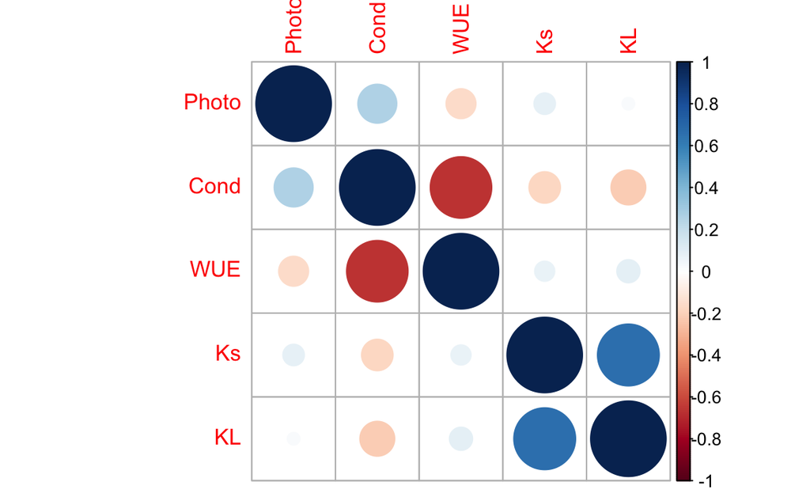

```r
protea_resid <- data.frame(Individual = seq(from = 1, to = nrow(dat)),
                           Ks = residuals(fit$Ks),
                           KL = residuals(fit$KL_Units),
                           Photo = residuals(fit$Photo),
                           Cond = residuals(fit$Cond),
                           WUE = residuals(fit$WUE_Intrinsic))
corrplot(cor(protea_resid[, c("Ks", "KL", "Photo", "Cond", "WUE")]), order = "hclust")
```

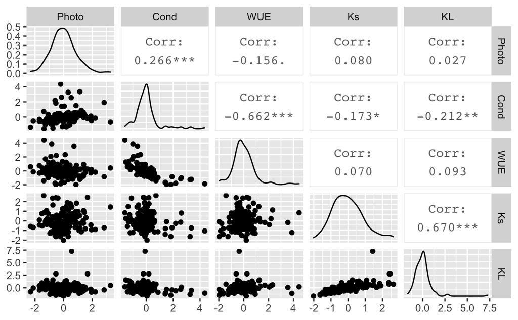

```r
ggpairs(protea_resid[, c("Photo", "Cond", "WUE", "Ks", "KL")])
```

Not surprisingly, the residuals of `Ks` and `KL` are strongly correlated, and the residuals of `Cond` and `WUE` are strongly negatively correlated. The residuals of `Photo` have a noticeable positive correlation with those of `Cond`. In fact, the residuals of `Cond` have noticeable associations with every response.

What that all means is that even after accounting for the influence of the morphological traits on these responses, the responses still remain associated,. As a result, it may be a little misleading to look at the individual associations of physiological responses with morphological traits. Mathematically, what we’ve done is this:

$$y_i = \beta_0 + \sum_k \beta_k X_{ik} + \epsilon_i \quad ,$$

where $y_i$ is the physiological response in individual $i$, and $\epsilon_i$ is the random error, which we assumed was $\mbox{N}(0, \sigma^2)$. We also implicitly assumed that $\epsilon_i$ in the regression of $Ks$ on morphological traits was independent of $\epsilon_i$ in the regression of other physiological responses. The correlation analysis above shows us how problematic that assumption is. What we should do instead is fit a model like this:

$$y_{it} = \beta_{0t} + \sum_k \beta_{kt}X_{ikt} + \epsilon_{it} \quad ,$$

where the subscript $t$ refers to the different physiological responses and $\epsilon_{it}$ is multivariate normal, $\mbox{MVN}({\bf 0}, \Sigma)$. How do we fit that? `brms` makes it easy.

```r
## the individual regressions
##
bf_Ks <- bf(Ks ~ WD + BW_dry_avg + Thick_cm + Area_cm2 + LMA_g.cm2 + LWR + LD_g.cm3  +
                  Length_mm_Top + Density_mm2_Top + SPI_Top)
bf_KL <- bf(KL_Units ~ WD + BW_dry_avg + Thick_cm + Area_cm2 + LMA_g.cm2 + LWR + LD_g.cm3  +
                  Length_mm_Top + Density_mm2_Top + SPI_Top)
bf_Photo <- bf(Photo ~ WD + BW_dry_avg + Thick_cm + Area_cm2 + LMA_g.cm2 + LWR + LD_g.cm3  +
                  Length_mm_Top + Density_mm2_Top + SPI_Top)
bf_Cond <- bf(Cond ~ WD + BW_dry_avg + Thick_cm + Area_cm2 + LMA_g.cm2 + LWR + LD_g.cm3  +
                  Length_mm_Top + Density_mm2_Top + SPI_Top)
bf_WUE <- bf(WUE_Intrinsic ~ WD + BW_dry_avg + Thick_cm + Area_cm2 + LMA_g.cm2 + LWR + LD_g.cm3  +
                  Length_mm_Top + Density_mm2_Top + SPI_Top)

## the brms model
##
fit_brm <- brm(bf_Ks + bf_KL + bf_Photo + bf_Cond + bf_WUE + set_rescor(TRUE),
           data = dat,
           chains = 4,
           cores = 4,
           silent = TRUE,
           refresh = 0,
           control = list(adapt_delta = 0.99))
```

```
There were 2 transitions after warmup that exceeded the maximum treedepth. Increase max_treedepth above 10. See
http://mc-stan.org/misc/warnings.html#maximum-treedepth-exceededExamine the pairs() plot to diagnose sampling problems
```

```r
summary(fit_brm, digits = 3)
```

```
 Family: MV(gaussian, gaussian, gaussian, gaussian, gaussian)
  Links: mu = identity; sigma = identity
         mu = identity; sigma = identity
         mu = identity; sigma = identity
         mu = identity; sigma = identity
         mu = identity; sigma = identity
Formula: Ks ~ WD + BW_dry_avg + Thick_cm + Area_cm2 + LMA_g.cm2 + LWR + LD_g.cm3 + Length_mm_Top + Density_mm2_Top + SPI_Top
         KL_Units ~ WD + BW_dry_avg + Thick_cm + Area_cm2 + LMA_g.cm2 + LWR + LD_g.cm3 + Length_mm_Top + Density_mm2_Top + SPI_Top
         Photo ~ WD + BW_dry_avg + Thick_cm + Area_cm2 + LMA_g.cm2 + LWR + LD_g.cm3 + Length_mm_Top + Density_mm2_Top + SPI_Top
         Cond ~ WD + BW_dry_avg + Thick_cm + Area_cm2 + LMA_g.cm2 + LWR + LD_g.cm3 + Length_mm_Top + Density_mm2_Top + SPI_Top
         WUE_Intrinsic ~ WD + BW_dry_avg + Thick_cm + Area_cm2 + LMA_g.cm2 + LWR + LD_g.cm3 + Length_mm_Top + Density_mm2_Top + SPI_Top
   Data: dat (Number of observations: 151)
Samples: 4 chains, each with iter = 2000; warmup = 1000; thin = 1;
         total post-warmup samples = 4000

Population-Level Effects:
                             Estimate Est.Error l-95% CI u-95% CI Rhat Bulk_ESS Tail_ESS
Ks_Intercept                     0.00      0.08    -0.15     0.15 1.00     4566     3022
KLUnits_Intercept                0.00      0.08    -0.15     0.15 1.00     4392     3036
Photo_Intercept                  0.00      0.07    -0.14     0.14 1.00     4982     3305
Cond_Intercept                  -0.00      0.07    -0.15     0.15 1.00     4063     2606
WUEIntrinsic_Intercept           0.00      0.08    -0.15     0.16 1.00     4453     3159
Ks_WD                           -0.15      0.11    -0.36     0.06 1.00     3522     3167
Ks_BW_dry_avg                   -0.12      0.18    -0.47     0.24 1.00     3241     3170
Ks_Thick_cm                     -0.35      0.69    -1.73     0.97 1.00     1821     1904
Ks_Area_cm2                     -0.21      0.17    -0.55     0.13 1.00     3111     3140
Ks_LMA_g.cm2                     0.39      0.62    -0.80     1.61 1.00     1840     1525
Ks_LWR                           0.17      0.18    -0.20     0.52 1.00     3512     2821
Ks_LD_g.cm3                     -0.64      0.47    -1.57     0.25 1.00     1805     1926
Ks_Length_mm_Top                 1.10      0.62    -0.12     2.34 1.00     1912     2494
Ks_Density_mm2_Top               0.61      0.38    -0.10     1.38 1.00     1954     2602
Ks_SPI_Top                      -0.54      0.35    -1.24     0.17 1.00     1956     2471
KLUnits_WD                      -0.03      0.11    -0.25     0.18 1.00     3215     2693
KLUnits_BW_dry_avg              -0.19      0.19    -0.56     0.18 1.00     3434     2846
KLUnits_Thick_cm                -0.87      0.70    -2.25     0.49 1.00     1802     1908
KLUnits_Area_cm2                -0.23      0.18    -0.59     0.12 1.00     3327     2838
KLUnits_LMA_g.cm2                0.68      0.63    -0.57     1.88 1.00     1829     1821
KLUnits_LWR                     -0.22      0.18    -0.57     0.14 1.00     3534     3273
KLUnits_LD_g.cm3                -0.75      0.47    -1.67     0.17 1.00     1800     2013
KLUnits_Length_mm_Top            0.49      0.63    -0.77     1.70 1.00     1842     2620
```

[output cut: 42 more lines]

```
                             Estimate Est.Error l-95% CI u-95% CI Rhat Bulk_ESS Tail_ESS
rescor(Ks,KLUnits)               0.65      0.05     0.55     0.74 1.00     3786     3247
rescor(Ks,Photo)                 0.08      0.08    -0.09     0.24 1.00     5117     2315
rescor(KLUnits,Photo)            0.03      0.09    -0.14     0.20 1.00     5214     3217
rescor(Ks,Cond)                 -0.16      0.08    -0.32    -0.00 1.00     3499     2711
rescor(KLUnits,Cond)            -0.20      0.08    -0.35    -0.05 1.00     3290     3433
rescor(Photo,Cond)               0.26      0.08     0.10     0.41 1.00     3390     3079
rescor(Ks,WUEIntrinsic)          0.06      0.08    -0.10     0.22 1.00     3816     2853
rescor(KLUnits,WUEIntrinsic)     0.08      0.08    -0.08     0.24 1.00     3508     3298
rescor(Photo,WUEIntrinsic)      -0.15      0.08    -0.30     0.02 1.00     4457     3011
rescor(Cond,WUEIntrinsic)       -0.65      0.05    -0.74    -0.54 1.00     4306     3588

Samples were drawn using sampling(NUTS). For each parameter, Bulk_ESS
and Tail_ESS are effective sample size measures, and Rhat is the potential
scale reduction factor on split chains (at convergence, Rhat = 1).
```

To make the results easier to compare let’s plot the posterior means for coefficients from the separate regression against the results from the multiple response regression for each response.

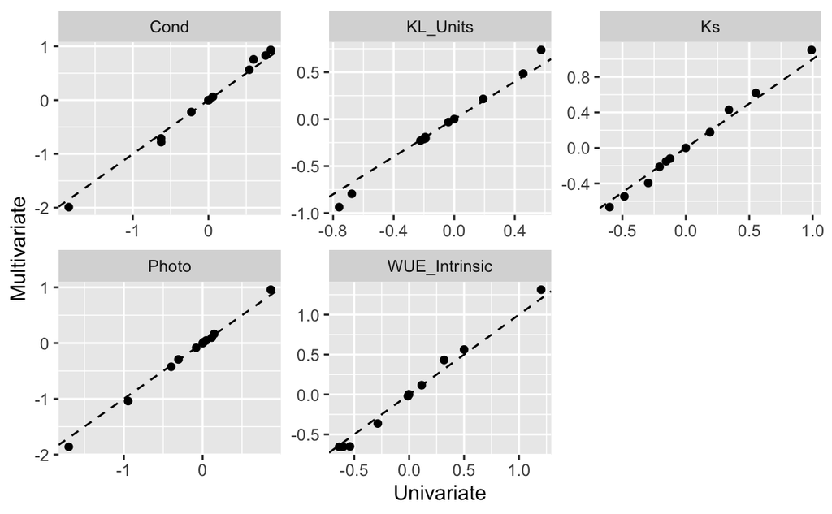

```r
brm_df <- as.data.frame(fit_brm)
for_plot <- data.frame(Response = NULL,
                       Univariate = NULL,
                       Multivariate = NULL,
                       Trait = NULL)
for (phys in phys_traits) {
  tmp <- as.data.frame(fit[[phys]])
  for(trait in colnames(tmp)) {
    if (trait == "sigma") {
      next;
    }
    if (trait == "(Intercept)") {
      trait_brm <- "Intercept"
    } else {
      trait_brm <- trait
    }
    if (phys == "KL_Units") {
      brm_var <- paste("b_KLUnits_", trait_brm, sep = "")
    } else if (phys == "WUE_Intrinsic") {
      brm_var <- paste("b_WUEIntrinsic_", trait_brm, sep = "")
    } else {
      brm_var <- paste("b_", phys, "_", trait_brm, sep = "")
    }
    tmp_df <- data.frame(Response = phys,
                         Univariate = mean(tmp[[trait]]),
                         Multivariate = mean(brm_df[[brm_var]]),
                         Trait = trait)
    for_plot <- rbind(for_plot, tmp_df)
  }
}

p <- ggplot(for_plot, aes(x = Univariate, y = Multivariate)) +
  geom_point() +
  geom_abline(slope = 1.0, intercept = 0.0, linetype = "dashed") +
  facet_wrap(~ Response, scales = "free")
print(p)
```

The point estimates are very similar, so why bother with the multivariate response? So far, there really isn’t much point, because all we’ve done is

1. Fit the five regressions simultaneously.
2. Estimate the residual correlations as part of fitting the model.

Let’s see what happens if we add the random site effect nested within species using the familiar `lmer()` or `stan_glmer()` syntax.

```r
## the individual regressions
##
bf_Ks <- bf(Ks ~ WD + BW_dry_avg + Thick_cm + Area_cm2 + LMA_g.cm2 + LWR + LD_g.cm3  +
                  Length_mm_Top + Density_mm2_Top + SPI_Top + (1|Species/Site))
bf_KL <- bf(KL_Units ~ WD + BW_dry_avg + Thick_cm + Area_cm2 + LMA_g.cm2 + LWR + LD_g.cm3  +
                  Length_mm_Top + Density_mm2_Top + SPI_Top + (1|Species/Site))
bf_Photo <- bf(Photo ~ WD + BW_dry_avg + Thick_cm + Area_cm2 + LMA_g.cm2 + LWR + LD_g.cm3  +
                  Length_mm_Top + Density_mm2_Top + SPI_Top + (1|Species/Site))
bf_Cond <- bf(Cond ~ WD + BW_dry_avg + Thick_cm + Area_cm2 + LMA_g.cm2 + LWR + LD_g.cm3  +
                  Length_mm_Top + Density_mm2_Top + SPI_Top + (1|Species/Site))
bf_WUE <- bf(WUE_Intrinsic ~ WD + BW_dry_avg + Thick_cm + Area_cm2 + LMA_g.cm2 + LWR + LD_g.cm3  +
                  Length_mm_Top + Density_mm2_Top + SPI_Top + (1|Species/Site))

## the brms model
##
fit_brm_rnd <- brm(bf_Ks + bf_KL + bf_Photo + bf_Cond + bf_WUE + set_rescor(TRUE),
                   data = dat,
                   chains = 4,
                   cores = 4,
                   silent = TRUE,
                   refresh = 0,
                   control = list(adapt_delta = 0.99))
```

```
There were 54 transitions after warmup that exceeded the maximum treedepth. Increase max_treedepth above 10. See
http://mc-stan.org/misc/warnings.html#maximum-treedepth-exceededExamine the pairs() plot to diagnose sampling problems
```

```r
summary(fit_brm_rnd, digits = 3)
```

```
 Family: MV(gaussian, gaussian, gaussian, gaussian, gaussian)
  Links: mu = identity; sigma = identity
         mu = identity; sigma = identity
         mu = identity; sigma = identity
         mu = identity; sigma = identity
         mu = identity; sigma = identity
Formula: Ks ~ WD + BW_dry_avg + Thick_cm + Area_cm2 + LMA_g.cm2 + LWR + LD_g.cm3 + Length_mm_Top + Density_mm2_Top + SPI_Top + (1 | Species/Site)
         KL_Units ~ WD + BW_dry_avg + Thick_cm + Area_cm2 + LMA_g.cm2 + LWR + LD_g.cm3 + Length_mm_Top + Density_mm2_Top + SPI_Top + (1 | Species/Site)
         Photo ~ WD + BW_dry_avg + Thick_cm + Area_cm2 + LMA_g.cm2 + LWR + LD_g.cm3 + Length_mm_Top + Density_mm2_Top + SPI_Top + (1 | Species/Site)
         Cond ~ WD + BW_dry_avg + Thick_cm + Area_cm2 + LMA_g.cm2 + LWR + LD_g.cm3 + Length_mm_Top + Density_mm2_Top + SPI_Top + (1 | Species/Site)
         WUE_Intrinsic ~ WD + BW_dry_avg + Thick_cm + Area_cm2 + LMA_g.cm2 + LWR + LD_g.cm3 + Length_mm_Top + Density_mm2_Top + SPI_Top + (1 | Species/Site)
   Data: dat (Number of observations: 151)
Samples: 4 chains, each with iter = 2000; warmup = 1000; thin = 1;
         total post-warmup samples = 4000

Group-Level Effects:
~Species (Number of levels: 5)
                           Estimate Est.Error l-95% CI u-95% CI Rhat Bulk_ESS Tail_ESS
sd(Ks_Intercept)               0.99      0.70     0.04     2.75 1.00     1824     1681
sd(KLUnits_Intercept)          0.84      0.65     0.04     2.47 1.00     1814     1856
sd(Photo_Intercept)            0.73      0.64     0.03     2.40 1.00     1909     2399
sd(Cond_Intercept)             0.69      0.59     0.03     2.19 1.00     1913     2665
sd(WUEIntrinsic_Intercept)     0.51      0.49     0.02     1.83 1.00     2410     2635

~Species:Site (Number of levels: 9)
                           Estimate Est.Error l-95% CI u-95% CI Rhat Bulk_ESS Tail_ESS
sd(Ks_Intercept)               0.79      0.38     0.28     1.73 1.00     1477     2002
sd(KLUnits_Intercept)          0.72      0.35     0.26     1.60 1.00     1887     2751
sd(Photo_Intercept)            0.94      0.37     0.45     1.88 1.00     1973     2415
sd(Cond_Intercept)             0.98      0.35     0.52     1.87 1.00     2547     2853
sd(WUEIntrinsic_Intercept)     0.91      0.33     0.49     1.72 1.00     2337     2829

Population-Level Effects:
                             Estimate Est.Error l-95% CI u-95% CI Rhat Bulk_ESS Tail_ESS
Ks_Intercept                    -0.17      0.58    -1.41     0.96 1.00     2830     2676
KLUnits_Intercept                0.07      0.53    -0.96     1.17 1.00     2503     2489
Photo_Intercept                 -0.13      0.52    -1.27     0.91 1.00     2308     1965
Cond_Intercept                  -0.15      0.53    -1.31     0.82 1.00     2257     2358
WUEIntrinsic_Intercept          -0.08      0.45    -0.99     0.79 1.00     1941     1976
Ks_WD                           -0.11      0.11    -0.32     0.10 1.00     4819     3243
```

[output cut: 59 more lines]

```
                             Estimate Est.Error l-95% CI u-95% CI Rhat Bulk_ESS Tail_ESS
rescor(Ks,KLUnits)               0.61      0.06     0.50     0.71 1.00     4283     3546
rescor(Ks,Photo)                 0.12      0.09    -0.05     0.29 1.00     6350     2728
rescor(KLUnits,Photo)            0.08      0.09    -0.09     0.24 1.00     6329     3086
rescor(Ks,Cond)                 -0.05      0.09    -0.22     0.13 1.00     5729     3217
rescor(KLUnits,Cond)            -0.01      0.09    -0.19     0.16 1.00     5841     3398
rescor(Photo,Cond)              -0.05      0.09    -0.22     0.12 1.00     5415     3485
rescor(Ks,WUEIntrinsic)          0.03      0.09    -0.14     0.21 1.00     4871     3062
rescor(KLUnits,WUEIntrinsic)    -0.01      0.09    -0.19     0.17 1.00     5089     3063
rescor(Photo,WUEIntrinsic)       0.09      0.08    -0.08     0.25 1.00     5058     2912
rescor(Cond,WUEIntrinsic)       -0.44      0.07    -0.57    -0.29 1.00     5037     3306

Samples were drawn using sampling(NUTS). For each parameter, Bulk_ESS
and Tail_ESS are effective sample size measures, and Rhat is the potential
scale reduction factor on split chains (at convergence, Rhat = 1).
```

You can see that the estimated residual correlations are now a bit smaller, but they’re not gone. If you’ve been paying attention, you may also be wondering about the random effects. “I put them in separately for each regression. Wouldn’t I get the same results if I just ran five regressions with random effects?” I won’t run the those regressions. I’ll let you do that on your own, but the answer is yes. What’s missing is that the random effects may be correlated across regressions.

`brms` extended the basic `lmer()` syntax to allow us to allow random effects to be correlated across regressions.[^2] Rather than writing `(1|Species/Site)` in each model to nest site within species I’d like to write `(1|ID|Species/Site)` to indicate that the random effects are correlated. Unfortunately, it’s not quite that simple. Remember that `(1|Species/Site)` is equivalent to `(1|Species) + (1|Species:Site)`. Each grouping factor needs its own `ID`, so we’ll need to write `(1|ID1|Species) + (1|ID2|Species:Site)`.[^3}

Let’s see what happens when we add an `ID` term to the random effects.

```r
bf_Ks <- bf(Ks ~ WD + BW_dry_avg + Thick_cm + Area_cm2 + LMA_g.cm2 + LWR + LD_g.cm3  +
                  Length_mm_Top + Density_mm2_Top + SPI_Top +
                  (1|ID1|Species) + (1|ID2|Species:Site))
bf_KL <- bf(KL_Units ~ WD + BW_dry_avg + Thick_cm + Area_cm2 + LMA_g.cm2 + LWR + LD_g.cm3  +
                  Length_mm_Top + Density_mm2_Top + SPI_Top +
                  (1|ID1|Species) + (1|ID2|Species:Site))
bf_Photo <- bf(Photo ~ WD + BW_dry_avg + Thick_cm + Area_cm2 + LMA_g.cm2 + LWR + LD_g.cm3  +
                  Length_mm_Top + Density_mm2_Top + SPI_Top +
                  (1|ID1|Species) + (1|ID2|Species:Site))
bf_Cond <- bf(Cond ~ WD + BW_dry_avg + Thick_cm + Area_cm2 + LMA_g.cm2 + LWR + LD_g.cm3  +
                  Length_mm_Top + Density_mm2_Top + SPI_Top +
                  (1|ID1|Species) + (1|ID2|Species:Site))
bf_WUE <- bf(WUE_Intrinsic ~ WD + BW_dry_avg + Thick_cm + Area_cm2 + LMA_g.cm2 + LWR + LD_g.cm3  +
                  Length_mm_Top + Density_mm2_Top + SPI_Top +
                  (1|ID1|Species) + (1|ID2|Species:Site))

## the brms model
##
fit_brm_multi <- brm(bf_Ks + bf_KL + bf_Photo + bf_Cond + bf_WUE + set_rescor(TRUE),
                     data = dat,
                     chains = 4,
                     cores = 4,
                     silent = TRUE,
                     refresh = 0,
                     control = list(adapt_delta = 0.99))
```

```
There were 1 transitions after warmup that exceeded the maximum treedepth. Increase max_treedepth above 10. See
http://mc-stan.org/misc/warnings.html#maximum-treedepth-exceededExamine the pairs() plot to diagnose sampling problems
```

```r
summary(fit_brm_multi, digits = 3)
```

```
 Family: MV(gaussian, gaussian, gaussian, gaussian, gaussian)
  Links: mu = identity; sigma = identity
         mu = identity; sigma = identity
         mu = identity; sigma = identity
         mu = identity; sigma = identity
         mu = identity; sigma = identity
Formula: Ks ~ WD + BW_dry_avg + Thick_cm + Area_cm2 + LMA_g.cm2 + LWR + LD_g.cm3 + Length_mm_Top + Density_mm2_Top + SPI_Top + (1 | ID1 | Species) + (1 | ID2 | Species:Site)
         KL_Units ~ WD + BW_dry_avg + Thick_cm + Area_cm2 + LMA_g.cm2 + LWR + LD_g.cm3 + Length_mm_Top + Density_mm2_Top + SPI_Top + (1 | ID1 | Species) + (1 | ID2 | Species:Site)
         Photo ~ WD + BW_dry_avg + Thick_cm + Area_cm2 + LMA_g.cm2 + LWR + LD_g.cm3 + Length_mm_Top + Density_mm2_Top + SPI_Top + (1 | ID1 | Species) + (1 | ID2 | Species:Site)
         Cond ~ WD + BW_dry_avg + Thick_cm + Area_cm2 + LMA_g.cm2 + LWR + LD_g.cm3 + Length_mm_Top + Density_mm2_Top + SPI_Top + (1 | ID1 | Species) + (1 | ID2 | Species:Site)
         WUE_Intrinsic ~ WD + BW_dry_avg + Thick_cm + Area_cm2 + LMA_g.cm2 + LWR + LD_g.cm3 + Length_mm_Top + Density_mm2_Top + SPI_Top + (1 | ID1 | Species) + (1 | ID2 | Species:Site)
   Data: dat (Number of observations: 151)
Samples: 4 chains, each with iter = 2000; warmup = 1000; thin = 1;
         total post-warmup samples = 4000

Group-Level Effects:
~Species (Number of levels: 5)
                                              Estimate Est.Error l-95% CI u-95% CI Rhat
sd(Ks_Intercept)                                  1.04      0.74     0.06     2.86 1.00
sd(KLUnits_Intercept)                             0.80      0.64     0.04     2.41 1.00
sd(Photo_Intercept)                               0.77      0.67     0.03     2.48 1.00
sd(Cond_Intercept)                                0.71      0.60     0.03     2.24 1.00
sd(WUEIntrinsic_Intercept)                        0.60      0.55     0.02     2.05 1.00
cor(Ks_Intercept,KLUnits_Intercept)               0.13      0.40    -0.67     0.82 1.00
cor(Ks_Intercept,Photo_Intercept)                 0.13      0.41    -0.71     0.84 1.00
cor(KLUnits_Intercept,Photo_Intercept)            0.03      0.41    -0.74     0.77 1.00
cor(Ks_Intercept,Cond_Intercept)                  0.00      0.40    -0.76     0.74 1.00
cor(KLUnits_Intercept,Cond_Intercept)            -0.07      0.41    -0.79     0.75 1.00
cor(Photo_Intercept,Cond_Intercept)               0.05      0.41    -0.73     0.80 1.00
cor(Ks_Intercept,WUEIntrinsic_Intercept)          0.01      0.42    -0.77     0.77 1.00
cor(KLUnits_Intercept,WUEIntrinsic_Intercept)    -0.02      0.43    -0.79     0.76 1.00
cor(Photo_Intercept,WUEIntrinsic_Intercept)       0.02      0.42    -0.76     0.77 1.00
cor(Cond_Intercept,WUEIntrinsic_Intercept)       -0.02      0.42    -0.76     0.76 1.00
                                              Bulk_ESS Tail_ESS
sd(Ks_Intercept)                                  1713     1824
sd(KLUnits_Intercept)                             1923     2187
sd(Photo_Intercept)                               2090     2160
sd(Cond_Intercept)                                2454     2916
sd(WUEIntrinsic_Intercept)                        2661     2623
cor(Ks_Intercept,KLUnits_Intercept)               4377     2824
```

[output cut: 111 more lines]

```
                             Estimate Est.Error l-95% CI u-95% CI Rhat Bulk_ESS Tail_ESS
rescor(Ks,KLUnits)               0.61      0.06     0.49     0.71 1.00     4549     2912
rescor(Ks,Photo)                 0.12      0.09    -0.05     0.29 1.00     5958     2432
rescor(KLUnits,Photo)            0.08      0.09    -0.09     0.24 1.00     6170     3400
rescor(Ks,Cond)                 -0.04      0.09    -0.21     0.12 1.00     6517     3251
rescor(KLUnits,Cond)            -0.01      0.09    -0.18     0.16 1.00     5842     3176
rescor(Photo,Cond)              -0.05      0.09    -0.22     0.12 1.00     5317     2920
rescor(Ks,WUEIntrinsic)          0.03      0.08    -0.14     0.19 1.00     5926     3325
rescor(KLUnits,WUEIntrinsic)    -0.01      0.09    -0.18     0.16 1.00     5344     3207
rescor(Photo,WUEIntrinsic)       0.09      0.08    -0.08     0.25 1.00     5665     3431
rescor(Cond,WUEIntrinsic)       -0.44      0.07    -0.56    -0.29 1.00     4382     3249

Samples were drawn using sampling(NUTS). For each parameter, Bulk_ESS
and Tail_ESS are effective sample size measures, and Rhat is the potential
scale reduction factor on split chains (at convergence, Rhat = 1).
```

Let’s compare the coefficient estimates from the multiple response model in which random effects are treated independently across the responses with the one we just fit in which they are correlated.

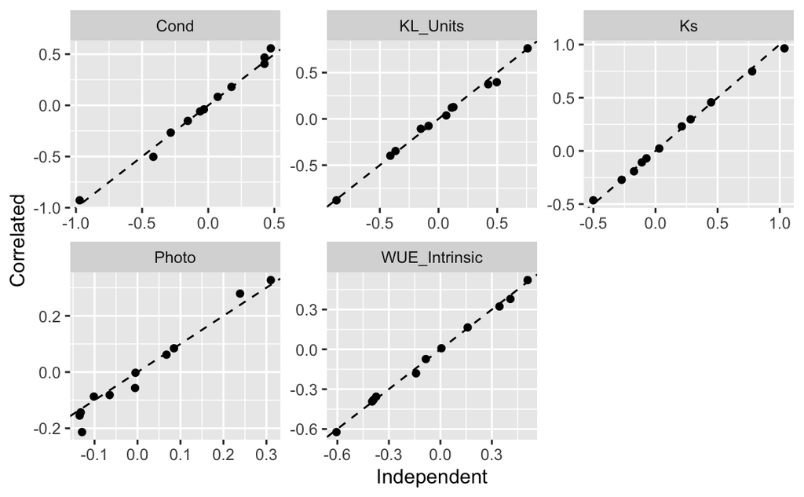

```r
brm_df_rnd <- as.data.frame(fit_brm_rnd)
brm_df <- as.data.frame(fit_brm_multi)
for_plot <- data.frame(Response = NULL,
                       Independent = NULL,
                       Correlated = NULL,
                       Trait = NULL)
for (phys in phys_traits) {
  tmp <- as.data.frame(fit[[phys]])
  for(trait in colnames(tmp)) {
    if (trait == "sigma") {
      next;
    }
    if (trait == "(Intercept)") {
      trait_brm <- "Intercept"
    } else {
      trait_brm <- trait
    }
    if (phys == "KL_Units") {
      brm_var <- paste("b_KLUnits_", trait_brm, sep = "")
    } else if (phys == "WUE_Intrinsic") {
      brm_var <- paste("b_WUEIntrinsic_", trait_brm, sep = "")
    } else {
      brm_var <- paste("b_", phys, "_", trait_brm, sep = "")
    }
    tmp_df <- data.frame(Response = phys,
                         Independent = mean(brm_df_rnd[[brm_var]]),
                         Correlated = mean(brm_df[[brm_var]]),
                         Trait = trait)
    for_plot <- rbind(for_plot, tmp_df)
  }
}

p <- ggplot(for_plot, aes(x = Independent, y = Correlated)) +
  geom_point() +
  geom_abline(slope = 1.0, intercept = 0.0, linetype = "dashed") +
  facet_wrap(~ Response, scales = "free")
print(p)
```

Given that the residual correlations in our latest model are pretty similar to what we saw before, it’s not too surprising that the full multiple response model, including correlations of random effects, doesn’t tell us anything different from what we could have concluded from five individual linear regressions.

In retrospect, that probably shouldn’t be surprising for this data set. There are only 151 observations[^3], and we’re fitting a regression with 10 independent variables *plus* a random site effect nested within a random species effect. As a result, the estimates of random effects are fairly imprecise. The credible intervals for species-level standard deviations range from about 0.03 to 2.5 for all of the regressions, and for the site-level standard deviations they range from about 0.3 to 2.0. Given how uncertain those estimates are, we shouldn’t be surprised that we are even more uncertain about how strongly the random effects are correlated across responses.

[^1]: Remember that for a “real” analysis, we’d include a random site effect nested within a random species effect.
[^2]: See Bürkner (https://cran.r-project.org/web/packages/brms/vignettes/brms_multilevel.pdf)[https://cran.r-project.org/web/packages/brms/vignettes/brms_multilevel.pdf] for details.
[^3]: Apologies to Kristen. She collected as many observations as she could given the physiological measurements she was making.